# The pursuit of the perfect viral metagenome: Decontamination using in vitro and in silico methods

```r
grp2.wizard.read.counts.wide <- read.delim(file = "poster_data/grp2_wizard_read_counts_wide.tsv"
                                   , sep = "\t"
                                   , header = TRUE
                                   , comment.char = "") %>%
dplyr::mutate(ace_sample = factor(ace_sample
                                   , levels = c("FECL030"
                                                , "FECL135"
                                                , "FECL025"))
              , prod_level = factor(case_when(ace_sample == "FECL030"
                                     ~ "Low"
                                     , ace_sample == "FECL135"
                                     ~ "Medium"
                                     , ace_sample == "FECL025"
                                     ~ "High")
                                    , levels = c("Low"
                                                 , "Medium"
                                                 , "High"))
              , treatment = factor(treatment
                                 , levels = c("W"
                                              , "DW"
                                              , "CW"
                                              , "CDW")
                                   , labels = c("No treatment"
                                                , "DNase"
                                                , "Chloroform"
                                                , "Chloroform\n+ DNase"))
                                              )
```

```r
## Convert all read data by superkingdom into long format
# for plotting
grp2.wizard.read.counts.long <- grp2.wizard.read.counts.wide %>%
  tidyr::pivot_longer(cols = c(13:29
                               , 33:50)
                      , names_to = c("read_type"
                                       , ".value")
                      , names_pattern = "(.*?)_(.*)") %>%
  dplyr::mutate(read_type = factor(read_type
                                       , levels = c("raw"
                                                    , "assembled"
                                                    , "binned")
                                   , labels = c("Reads"
                                                , "Assemblies"
                                                , "Bins")))
```

```r
grp2.wizard.pal <- c("royalblue1"
                     , "mediumblue"
                     , "midnightblue")

box.col <- "goldenrod1"
```

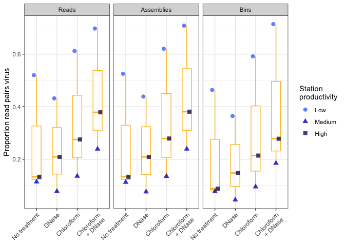

```r
ggplot2::ggplot(data = grp2.wizard.read.counts.long
                , aes(x = treatment
                      , y = readpair_class_Viruses/readpair_class_tot)) +
  geom_boxplot(color = box.col
               , width = 0.45) +
  geom_point(position = position_dodge(width = 0.4)
             , size = 2.5
             , alpha = 0.8
             , aes(color = prod_level
                   , shape = prod_level)) +
  facet_grid(.~read_type) +
  theme_bw() +
  theme(axis.text.x = element_text(angle = 45
                                   , hjust = 1
                                   , size = 9)) +
  labs(x = NULL
       , y = "Proportion read pairs virus") +
  scale_color_manual(values = grp2.wizard.pal
                     , name = "Station\nproductivity") +
  scale_shape_discrete(name = "Station\nproductivity")
```

```r
raw.read.lmm <- lmerTest::lmer(readpair_class_Viruses/readpair_class_tot ~ treatment + (1|prod_level)
               , grp2.wizard.read.counts.long
              , subset = read_type == "raw")
```

[output not shown]

```r
summary(raw.read.lmm)
```

[output not shown]

```r
assembled.read.lmm <- lmerTest::lmer(readpair_class_Viruses/readpair_class_tot ~ treatment + (1|prod_level)
               , grp2.wizard.read.counts.long
              , subset = read_type == "assembled")
```

[output not shown]

```r
summary(assembled.read.lmm)
```

[output not shown]

```r
binned.read.lmm <- lmerTest::lmer(readpair_class_Viruses/readpair_class_tot ~ treatment + (1|prod_level)
               , grp2.wizard.read.counts.long
              , subset = read_type == "binned")
```

[output not shown]

```r
summary(binned.read.lmm)
```

[output not shown]

## 3.2 Contiguous sequences: assembled and binned

Assemblies were classified as viral by VirSorter and VirFinder. All assemblies were run through both programs, and any assembly classified by either program was labeled as virus.

Example code for VirSorter:

```
wrapper_phage_contigs_sorter_iPlant.pl --virome -f $sample1 --db 1 --wdir "classifications/virsorter_ace_bins/"$sampledir"/" --ncpu 1 --data-dir /nfs/turbo/lsa-duhaimem/software/virsorter-data
```

Example code for VirFinder:

[output not shown]

## 3.3 References

Li H. and Durbin R. (2010) Fast and accurate long-read alignment with Burrows-Wheeler Transform. Bioinformatics, Epub. [PMID: 20080505]

Kim D, Song L, Breitwieser FP, and Salzberg SL. Centrifuge: rapid and sensitive classification of metagenomic sequences. Genome Research 2016

Roux, Simon, Jennifer R. Brum, Bas E. Dutilh, Shinichi Sunagawa, Melissa B. Duhaime, Alexander Loy, Bonnie T. Poulos et al. “Ecogenomics and potential biogeochemical impacts of globally abundant ocean viruses.” Nature 537, no. 7622 (2016): 689-693.

Beaulaurier, John, Elaine Luo, John M. Eppley, Paul Den Uyl, Xiaoguang Dai, Andrew Burger, Daniel J. Turner et al. “Assembly-free single-molecule sequencing recovers complete virus genomes from natural microbial communities.” Genome research 30, no. 3 (2020): 437-446.

## 3.4 Acknowledgements

A great big thanks to Jacob Evans for providing technical support at every step and Will Close for providing code to run VirSorter and VirFinder.